# Resampling Methods

Resampling Methods: involve repeatedly drawing samples from a training set and refitting a model of interest on each sample in order to obtain additional information about the fitted model.

For example: in order to estimate the variability of a linear regression fit, we can repeatedly draw different samples from the training data, fit a linear regression to each new sample, and then examine the extent to which the resulting fits differ.

Such an approach may allow us to obtain information that would not be available from fitting the model only once using the original training sample.

We discuss two of the most commonly used resampling methods: *cross-validation* and the *bootstrap*.

## Cross-Validation

### Validation Sets

In general: We are interested in test error performance: What happens in the absence of large designated test set?

- mathematical adjustment to the training error rate in order to estimate the test error rate.
- here: consider a class of methods that estimate the test error rate by holding out a subset of the training observations from the fitting process, and then applying the statistical learning method to those held out observations.

The simplest strategy: **Validation set approach.**

- Randomly divide the available set of observations into two parts, a training set and a validation set or hold-out set.
- fit the model on the training set.
- fitted model is used to predict the responses for the observations in the validation set.
- validation set error rate%—typically assessed using MSE in the case of a quantitative response— provides an estimate of the test error rate.

**The problem**: Test MSE highly dependent on the specific hold-out sample.

Does higher order polynomial of improve the fit of the model?

- randomly draw new validation set/randomly take new splits of the test and training data
- calculate test MSE for the various models fitted on the training data.
- If we repeat the process of randomly splitting the sample set/randomly draw new test sets , we will get a somewhat different estimate for the test MSE.

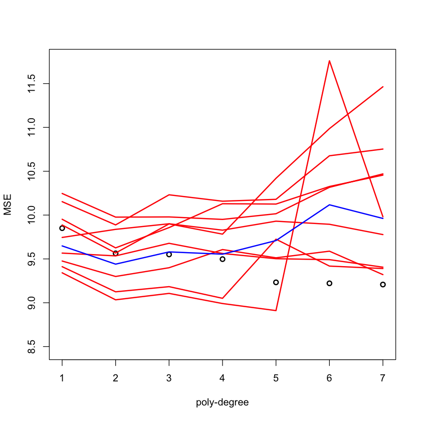

```r
set.seed(101)
n = 500
beta =c(5, -0.5)
varx=1.5
vare=10

tr_prop<-0.5

# a) ###generate the training data
x2 = rnorm(n=n, mean=0, sd=varx**0.5)
x1<-rep(1,n)
x = cbind(x1, x2)

emp = rnorm(n=n, mean=0, sd=vare**0.5)

y = x%*%beta + emp

############make into dataframe###################

data<-cbind(y,x)
train_ind <- sample(seq_len(nrow(data)), size = tr_prop*n)

data_training<- data[train_ind, ]
data_test <-data[-train_ind, ]


x2_train<-data_training[,3]
y_train<-data_training[,1]
x2_test<-data_test[,3]
y_test<-as.vector(data_test[,1])

########################################################
###calculate the error for the different polynomials####

x_train_ = matrix(data=rep(1, tr_prop*n), nrow=tr_prop*n, ncol=1)
x_test_ = matrix(data=rep(1, length(y_test)), nrow=length(y_test), ncol=1)
sim_rep=10
poly_degree<-6
mse_test_result = matrix(nrow = sim_rep, ncol = poly_degree + 1)
mse_train_result = matrix(nrow = sim_rep, ncol = poly_degree + 1)


for(sim in 1:sim_rep)
{
  data<-cbind(y,x)
  train_ind <- sample(seq_len(nrow(data)), size = tr_prop*n)
  data_training<- data[train_ind, ]
  data_test <-data[-train_ind, ]
  x2_train<-data_training[,3]
  y_train<-data_training[,1]
  x2_test<-data_test[,3]
  y_test<-as.vector(data_test[,1])

  ########################################################
  ###calculate the error for the different polynomials####

  x_train_ = matrix(data=rep(1, tr_prop*n), nrow=tr_prop*n, ncol=1)
  x_test_ = matrix(data=rep(1, length(y_test)), nrow=length(y_test), ncol=1)
  for (i in 0:poly_degree) {
    if (i > 0){
      x_train_ = cbind(x_train_, x2_train**i)
      x_test_ = cbind(x_test_, x2_test**i)
    }
    b_train = solve(t(x_train_)%*%x_train_)%*%(t(x_train_)%*%y_train)
    y_train_hat = x_train_%*%b_train
    mse_train = mean((y_train - y_train_hat)**2)
    y_test_hat = x_test_%*%b_train
    mse_test = mean((y_test - y_test_hat)**2)
    mse_train_result[sim,i + 1] = mean((y_train - y_train_hat)**2)
    mse_test_result[sim,i + 1]  = mean((y_test - y_test_hat)**2)
  }
}



plot(mse_train_result[1,],ylim=c(min(mse_test_result),max(mse_test_result)),ylab="MSE",xlab="poly-degree",lwd=2)
for(i in 2:sim_rep)
{
  lines(mse_test_result[i,],col="red",lwd=2)
}

mean_test<-colMeans(mse_test_result)
lines(mean_test,col="blue",lwd=2)
```

### Cross-Validation-Leave-One-Out

Leave-One-Out Cross-Validation (LOOCV): instead of creating two subsets of comparable size, a single observation $\left(x_{1}, y_{1}\right)$ is used for the validation set, and the remaining observations. $\left\{\left(x_{2}, y_{2}\right), \ldots,\left(x_{n}, y_{n}\right)\right\}$ make up the training set.

We fit on the $n - 1$ training observations, and a prediction $\hat{y}_{1}$ is made for the excluded observation, using its value ${x}_{1}$.

Because $\left(x_{1}, y_{1}\right)$ was not used in the fitting process $\mathrm{MSE}_{1}=\left(y_{1}-\hat{y}_{1}\right)^{2}$ provides an approximately unbiased estimate for the test error. But: it is a poor estimate because it is highly variable, since based upon a single observation.

Repeat the procedure by selecting $\left(x_{2}, y_{2}\right)$ for the validation data, training the statistical learning procedure on the $n -1$ observations $\left\{\left(x_{1}, y_{1}\right),\left(x_{3}, y_{3}\right), \ldots,\left(x_{n}, y_{n}\right)\right\}$ and computing $\mathrm{MSE}_{2}=\left(y_{2}-\hat{y}_{2}\right)^{2}$

Repeating this approach n times produces n squared errors $\mathrm{MSE}_{1}, \ldots, \mathrm{MSE}_{n}$ The LOOCV estimate for the test MSE is the average of these n test error estimates:

\begin{equation} \mathrm{CV}_{(n)}=\frac{1}{n} \sum_{i=1}^{n} \mathrm{MSE}_{i} \end{equation}

**Advantages of LOOCV**

- far less bias than validation set approach: use training sets that contain $n-1$ observations $\rightarrow$ LOOCV approach tends not to overestimate the test error rate as much as the validation set approach does.
- validation approach which will yield different results when applied repeatedly due to randomness in the training/validation set splits, performing LOOCV multiple times will always yield the same results: there is no randomness in the training/validation set splits, performing LOOCV multiple times will always yield the same results: there is no randomness in the training/validation set splits.

**Disadvantage of LOOCV:**

Potential to be computationally expensive to implement, the more so if $n$ is large and/or the model is slow to fit.

### K-Fold Cross-Validation

An alternative to LOOCV: k-fold CV. T

- randomly divide the set of observations into $k$ groups, aprr. equal size.
- first fold is treated as a validation set
- method is fit on the remaining $k-1$ folds
- MSE is then computed on the observations in the held-out fold
- procedure is repeated $k$ times; each time, a different group of observations is treated as a validation set

This process results in k estimates of the test error,

$\mathrm{MSE}_{1}, \mathrm{MSE}_{2}, \ldots, \mathrm{MSE}_{k}$ The k-fold CV estimate is computed by averaging these values,

\begin{equation} \mathrm{CV}_{(k)}=\frac{1}{k} \sum_{i=1}^{k} \mathrm{MSE}_{i} \end{equation}

LOOCV is a special case of $k$-fold CV in which $k$ is set to equal $n$.

Why use $k = 5$ or $k = 10$ rather than $k = n$? LOOCV: fitting the statistical learning method $n$ times. $k=10$: fit slm only 10 times.

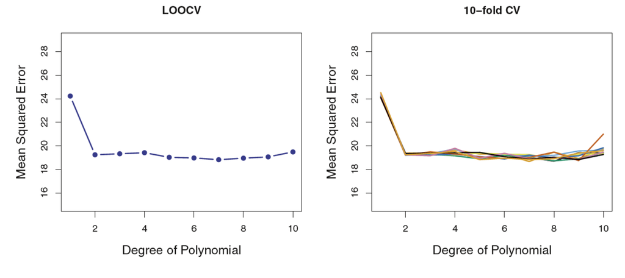

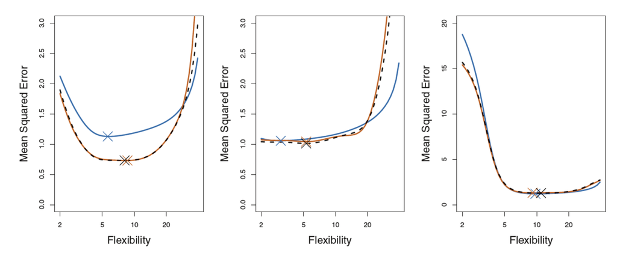

### Bias-Variance Trade-Off for $k$-Fold Cross-Validation

We know that:

- validation set approach overestimates of the test error rate
- LOOCV will give approximately unbiased estimates of the test error
- $\rightarrow$ $k$-fold CV will lead to an intermediate level of bias, since each training set contains $(k − 1)n/k$ observations—fewer than in the LOOCV approach, but substantially more than in the validation set approach.

Therefore, from the perspective of bias reduction: LOOCV $>$ k-fold CV.

But: LOOCV has higher variance than $k$-fold CV with $k < n$.

Why is this the case?

LOOCV averages the outputs of $n$ fitted models, each of which is trained on an almost identical set of observations: $\rightarrow$ outputs are highly (positively) correlated with each other.

In contrast, when we perform k-fold CV with $k < n$, we are averaging the outputs of k fitted models that are somewhat less correlated with each other, since the overlap between the training sets in each model is smaller.

### Cross-Validation on Classification Problems

\begin{equation} \mathrm{CV}_{(n)}=\frac{1}{n} \sum_{i=1}^{n} \operatorname{Err}_{i} \end{equation}

where $\operatorname{Err}_{i}=I\left(y_{i} \neq \hat{y}_{i}\right)$.

## The Bootstrap

The bootstrap approach can be used to assess the variability of the coefficient estimates and predictions from a statistical learning method by repeatedly sampling from the sample with replacement.

Suppose we have a model fit to a set of training data. We denote the training set by $Z=\left(z_{1}, z_{2}, \dots, z_{N}\right)$ where $z_{i}=\left(x_{i}, y_{i}\right)$

Basic idea: to randomly draw datasets with replacement from the training data, each sample the same size as the original training set. This is done B times ($B = 100$ say), producing $B$ bootstrap datasets.

Then we refit the model to each of the bootstrap datasets, and examine the behavior of the fits over the $B$ replications.

From this we let $S(\mathbf{Z})$ be any quantity computed from the data $\mathbf{Z}$, i.e. prediction at some input point.From the bootstrap sampling we can estimate any aspect of the distribution of $S(\mathbf{Z})$. \begin{equation} \widehat{\operatorname{Var}}[S(\mathbf{Z})]=\frac{1}{B-1} \sum_{b=1}^{B}\left(S\left(\mathbf{Z}^{* b}\right)-\overline{S}^{*}\right)^{2} \end{equation}

where $\overline{S}^{*}=\sum_{b} S\left(\mathbf{Z}^{* b}\right) / B$

To illustrate: toy example in which we wish to determine the best investment allocation under a simple model.

Suppose that we wish to invest a fixed sum of money in two financial assets that yield returns of $X$ and$ Y$

We will invest a fraction $\alpha$ of our money in $X$, and will invest the remaining $1-\alpha$ in $Y$.

Since there is variability associated with the returns on these two assets: we wish to choose $\alpha$ to minimize the total risk, or variance, of our investment, i.e. we minimize $\operatorname{Var}(\alpha X+(1-\alpha) Y)$. One can show that the value that minimizes the risk is given by

\begin{equation} \alpha=\frac{\sigma_{Y}^{2}-\sigma_{X Y}}{\sigma_{X}^{2}+\sigma_{Y}^{2}-2 \sigma_{X Y}} \end{equation}

where $\sigma_{X}^{2}=\operatorname{Var}(X), \sigma_{Y}^{2}=\operatorname{Var}(Y), \text { and } \sigma_{X Y}=\operatorname{Cov}(X, Y)$

In reality, the quantities $\sigma_{X}^{2}, \sigma_{Y}^{2}, \text { and } \sigma_{X Y}$ are unknown. \begin{equation}\label{eq_boot_II} \hat{\alpha}=\frac{\hat{\sigma}_{Y}^{2}-\hat{\sigma}_{X Y}}{\hat{\sigma}_{X}^{2}+\hat{\sigma}_{Y}^{2}-2 \hat{\sigma}_{X Y}} \end{equation}

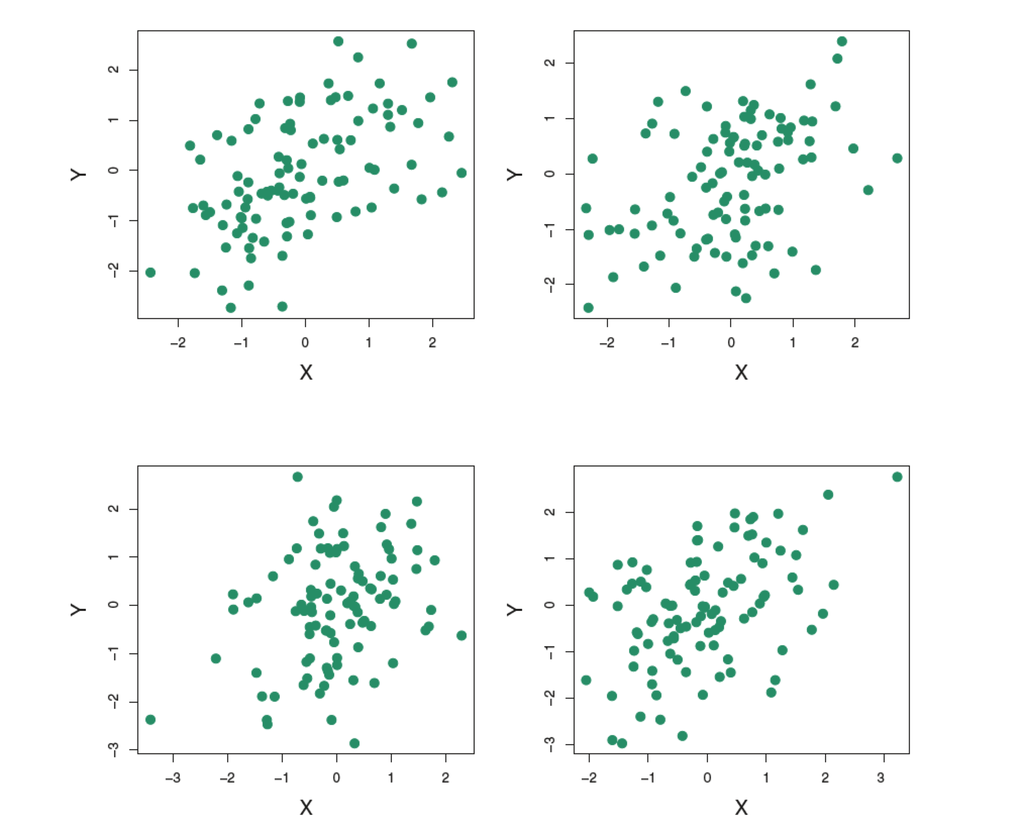

Mean value is given by:

$$ \overline{\alpha}=\frac{1}{1,000} \sum_{r=1}^{1,000} \hat{\alpha}_{r}=0.5996 $$

and the standard deviation

$$ \sqrt{\frac{1}{1,000-1} \sum_{r=1}^{1,000}\left(\hat{\alpha}_{r}-\overline{\alpha}\right)^{2}}=0.083 $$

What if we do not have enough new data sets to quantify uncertainty?

We randomly select $n$ observations from the data set in order to produce a bootstrap data set, $Z^{* 1}$ The sampling is performed with replacement.

Use $Z^{* 1}$ to calculate $\hat{\alpha}^{* 1}$.

This procedure is repeated B times for some large value of B, in order to produce B different bootstrap data sets, $Z^{* 1}, Z^{* 2}, \ldots, Z^{* B}$ and B corresponding $\alpha$ estimates $\hat{\alpha}^{* 1}, \hat{\alpha}^{* 2}, \ldots, \hat{\alpha}^{* B}$ We can compute the standard error of these bootstrap estimates using the formula

\begin{equation} \operatorname{SE}_{B}(\hat{\alpha})=\sqrt{\frac{1}{B-1} \sum_{r=1}^{B}\left(\hat{\alpha}^{* r}-\frac{1}{B} \sum_{r^{\prime}=1}^{B} \hat{\alpha}^{* r^{\prime}}\right)^{2}} \end{equation}

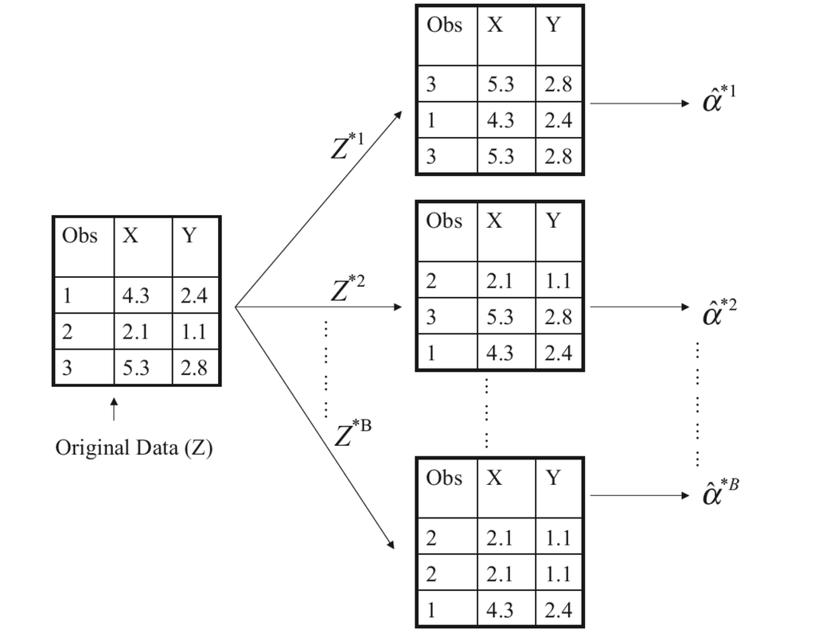

### The bootstrap confidence interval

Consistent confidence intervals can be constructed from the bootstrapped estimators. A two-sided with coverage $1-\alpha$ for a parameter $\theta$ is given by $$[\hat{\theta}_n-q_{1-\alpha/2},\hat{\theta}_n-q_{\alpha/2}]$$ where $q_{\alpha}=\alpha-$ quantile of $\hat{\theta}_n$. The bootstrap estimated confidence interval is the defined as

$$[\hat{\theta}_n-\hat{q}_{1-\alpha/2},\hat{\theta}_n-\hat{q}_{\alpha/2}]$$

where $\hat{q}_{\alpha}=\alpha-$ quantile of $\hat{\theta}^*_n-\theta$, where $\theta$ is the true parameter value. Due to invariance of the quantile: $$\hat{q}_{\alpha}={q}^*_{\alpha}-\hat{\theta}_n$$ where $\hat{q}^*_{\alpha}=\alpha-$ quantile of $\hat{\theta}^*_n-\hat{\theta}_n$.

Therefore, the bootstrap confidence interval becomes

$$[2\hat{\theta}_n-q^*_{1-\alpha/2},2\hat{\theta}_n-q^*_{\alpha/2}].$$

Note that this is not the simple bootstrap quantile. The reason for this is, that the bootstrap estimators are centered around the estimator $\hat{\theta}_n$, *not* around the true parameter $\theta$.

```r
#set.seed(100)
n=10

x<-rbinom(1,1,0.5)
X<-c(x,rep(x,le=(n-1)))
X
```

1. 0

2. 0

3. 0

4. 0

5. 0

6. 0

7. 0

8. 0

9. 0

10. 0

How can we apply the bootstrap to estimate prediction error? One ap- proach would be to fit the model in question on a set of bootstrap samples, and then keep track of how well it predicts the original training set.

$\hat{f}^{* b}\left(x_{i}\right)$ is the predicted value at xi, from the model fitted to the bth boot- strap dataset, our estimate is

\begin{equation} \widehat{\mathrm{Err}}_{\mathrm{boot}}=\frac{1}{B} \frac{1}{N} \sum_{b=1}^{B} \sum_{i=1}^{N} L\left(y_{i}, \hat{f}^{* b}\left(x_{i}\right)\right) \end{equation}

However, it is easy to see that $\widehat{\mathrm{Err}}_{\mathrm{boot}}$ does not provide a good estimate in general. The reason is that the bootstrap datasets are acting as the training samples, while the original training set is acting as the test sample, and these two samples have observations in common. This overlap can make overfit predictions look unrealistically good, and is the reason that cross- validation explicitly uses non-overlapping data for the training and test samples. Consider for example a 1-nearest neighbor classifier applied to a two-class classification problem with the same number of observations in each class, in which the predictors and class labels are in fact independent. Then the true error rate is 0.5. But the contributions to the bootstrap estimated $\widehat{\mathrm{Err}}_{\mathrm{boot}}$ will be zero unless the observation i does not appear in the bootstrap sample b. In this latter case it will have the correct expectation 0.5.

\begin{equation} \begin{aligned} \operatorname{Pr}\{\text { observation } i \in \text { bootstrap sample } b\} &=1-\left(1-\frac{1}{N}\right)^{N} \\ & \approx 1-e^{-1} \\ &=0.632 \end{aligned} \end{equation}

Hence the expectation of $\widehat{\mathrm{Err}}_{\mathrm{boot}}$ is about $0.5 × 0.368 = 0.184$, far below the correct error rate 0.5.

By mimicking cross-validation, a better bootstrap estimate can be obtained. For each observation, we only keep track of predictions from bootstrap samples not containing that observation. The leave-one-out bootstrap estimate of prediction error is defined by

\begin{equation} \widehat{\operatorname{Err}}^{(1)}=\frac{1}{N} \sum_{i=1}^{N} \frac{1}{\left|C^{-i}\right|} \sum_{b \in C^{-i}} L\left(y_{i}, \hat{f}^{* b}\left(x_{i}\right)\right) \end{equation}

here $C^{-i}$ is the set of indices of the bootstrap samples $b$ that do not contain observation $i$, and $\left|C^{-i}\right|$ is the number of such samples.

In computing $\widehat{\operatorname{Err}}^{(1)}$ we either have to choose B large enough to ensure that all of the $\left|C^{-i}\right|$ are greater than zero, or we can just leave out the terms in corresponding to $\left|C^{r-i}\right|$ s that are zero.

The leave-one out bootstrap solves the overfitting problem suffered by dErrboot, but has the training-set-size bias mentioned in the discussion of cross-validation. The average number of distinct observations in each boot- strap sample is about 0.632 ·N, so its bias will roughly behave like that of twofold cross-validation. Thus if the learning curve has considerable slope at sample size N/2, the leave-one out bootstrap will be biased upward as an estimate of the true error.